# 페이스북 잠재의미분석

1. Environment Setting & Packages loading

```r
setwd("C:\\Users\\kyuchul\\Documents\\Carrer\\RZIP")
packages <- c("Rfacebook","tm","lsa","wordcloud","ggplot2","KoNLP","GPArotation","cluster","RWeka","ROAuth","fpc","stringr","ape")
for(i in packages){
  library(i,character.only = T)
}
```

- 어떤 dictionary를 사용할 것인가

```r
useSejongDic()
```

```
Backup was just finished!
370957 words dictionary was built.
```

사전에 별도의 단어를 추가하기 위해서는 mergeUserDic(data.frame(c(“item1”,“item2..”),c(“품사”)))

- Setting

```r
pdf.options(family="Korea1deb") #not to tear down the letters
options(java.parameters=c("-Xmx4g","-Dfile.encoding=UTF-8")) #to increse heap size of rjava
pal <- brewer.pal(9,"Set1")
options(mc.cores=1)
```

2. 대나무숲 파일 로딩

```r
files <- list.files(pattern="*.csv")
# First apply read.csv, then rbind
myfiles = do.call(rbind, lapply(files, function(x) read.csv(x, stringsAsFactors = FALSE)))
file <- myfiles$content_coms
```

- iconv(~, “CP949”, “UTF-8)”CP949“로 인코딩된 ~라는 데이터에 저장된 문자열을”UTF-8“로 인코딩된 문자열로 변환

```r
file <- iconv(file, "CP949", "UTF-8")
```

3. 전처리
- file에서 내용이 시작하는 부분을 찾아냄 from : 처음으로 >등장하는 index + 2 to : 처음으로 :]이 등장하는 index -1 subtr로 그부분만 떼어냄
- 그리고 unname으로 file의 행이름을 지워줌
- 기타 이상한거 지움 주의점: replace를 " “로 해줘야 단어가 붙지 않고 떨어진다.

<비교> - “”로 했을 때: $`카톡 읽씹하지마찔리는분들은 답장해주세요` [1] “카톡” “읽씹하지마찔리는분들은” [3] “답장”  
- " “: $`카톡 읽씹하지마 찔리는분들은 답장해주세요` [1]”카톡" “읽씹하지마” “찔리는분들은” “답장”

```r
length(file)
```

```
[1] 8428
```

4. Building Corpus
- Extract Noun from txt

```r
save(txt_noun,file = "txt_noun.RData") #파일로 저장
```

- A vector source interprets each element of the vector x as a document.

```r
corpus <- Corpus(VectorSource(txt_noun))
```

- tm_map으로 다시한번 전처리

```r
corpus <- tm_map(corpus, stripWhitespace) #불필요한 공백 제거
```

- Document-Term Matrix

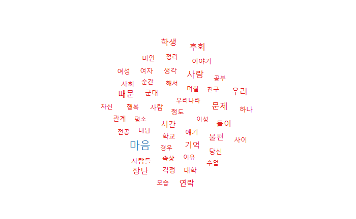

```r
wordcloud(terms,tt,scale=c(6,1),rot.per=0,max.words=50,color=pal)
```